# (PSL) Project 4 - Movie Recommendation

CS 598, Fall 2021, Bigyan Mishra (bigyanm2) (663725667), Ambalika Roy (aroy13), Swapnil Naik (ssnaik2)

Fall 2021

# TEAM

1. **Bigyan Mishra (bigyanm2) (663725667)**. EDA, system-I (part A), system-II design, Azure setup
2. **Ambalika Roy (aroy13)**. Shiny app dev, documentation
3. **Swapnil Naik (ssnaik2)**. System-I (part B), documentation, shiny app dev

# Part - I INTRODUCTION

We are provided with a dataset which contains about 1 million anonymous ratings of approximately 3,900 movies made by 6040 MovieLens users who joined MovieLens in 2000. As a part of this project, we will be creating two recommender systems on following themes:

1. **SYSTEM I**: *recommendation based on genres*. Suppose we know the user’s favorite genre. How would we recommend movies to user? We will propose two recommendation schemes based on this approach
2. **SYSTEM II**: *collaborative recommendation system*. We will review and evaluate *at least two* collaborative recommendation algorithms, for example, user-based, item-based, or SVD

#### Loading Libraries

```r
suppressPackageStartupMessages({
  library(dplyr)
  library(ggplot2)
  library(grid)
  library(gridExtra)
  library(Matrix)
  library(recommenderlab)
  library(data.table)
  library(tidyr)
}
)
```

# Part - II DATA

```r
# Ref: https://liangfgithub.github.io/Rcode_W13_Movie_EDA.nb.html

myurl = "https://liangfgithub.github.io/MovieData/"
```

## Load Ratings Data

```r
# Ref: https://liangfgithub.github.io/Rcode_W13_Movie_EDA.nb.html

read_ratings_start = Sys.time()

ratings = read.csv(paste0(myurl, 'ratings.dat?raw=true'), sep = ':', colClasses = c('integer', 'NULL'), header = FALSE)
read_ratings_time = Sys.time() - read_ratings_start
#print(read_movie_time)

colnames(ratings) = c('USERID', 'MOVIEID', 'RATING', 'TIMESTAMP')
```

## Load Movies Data

```r
movies = readLines(paste0(myurl, 'movies.dat?raw=true'))
movies = strsplit(movies, split = "::", fixed = TRUE, useBytes = TRUE)
movies = matrix(unlist(movies), ncol = 3, byrow = TRUE)
movies = data.frame(movies, stringsAsFactors = FALSE)
colnames(movies) = c('MOVIEID', 'TITLE', 'GENRES')

movies$MOVIEID = as.integer(movies$MOVIEID)

movies$TITLE = iconv(movies$TITLE, "latin1", "UTF-8")

movies$YEAR = as.numeric(unlist(
  lapply(movies$TITLE, function(x) substr(x, nchar(x)-4, nchar(x)-1))))
```

## Load Users Data

```r
users = read.csv(paste0(myurl, 'users.dat?raw=true'),
                 sep = ':', header = FALSE)
users = users[, -c(2,4,6,8)] # skip columns
colnames(users) = c('USERID', 'GENDER', 'AGE', 'OCCUPATION', 'ZIP')
```

# Part - III EXPLORATORY DATA ANALYSIS

## Ratings Data

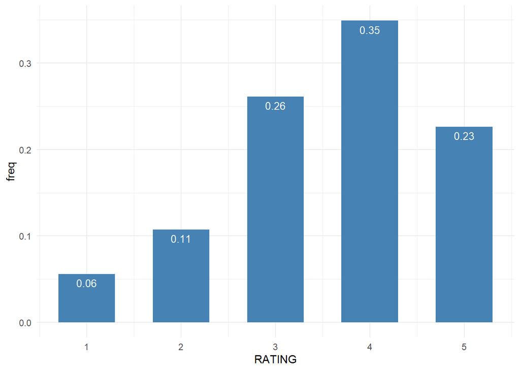

```r
tmp = data.frame(RATING = 1:5,
                 freq = as.vector(table(ratings$RATING)/nrow(ratings)))
ggplot(data = tmp, aes(x = RATING, y = freq)) +
  geom_bar(stat="identity", fill = 'steelblue', width = 0.6) +
  geom_text(aes(label=round(freq, dig=2)),
                vjust=1.6, color="white", size=3.5) +
  theme_minimal()
```

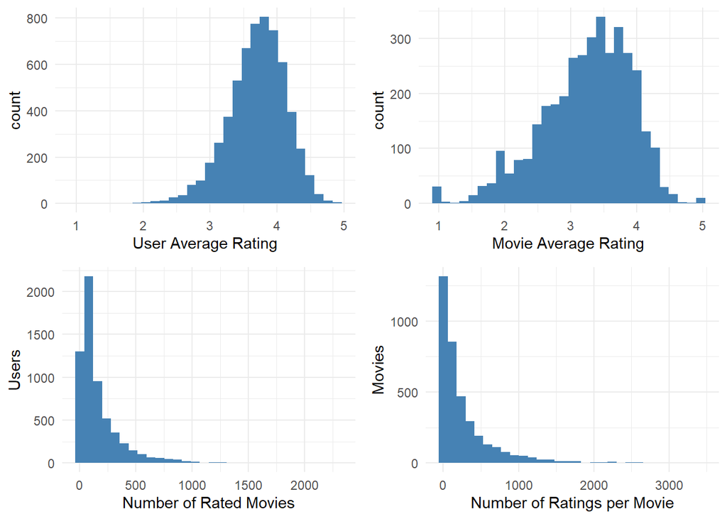

```r
usr_average_rat = ratings %>%
  group_by(USERID) %>%
  summarise(avgRating = mean(RATING), nRatings = n()) %>%
  ggplot(aes(x = avgRating)) +geom_histogram(fill='steelblue') +xlab('User Average Rating') + theme_minimal()

mov_avg_rating = ratings %>%
  group_by(USERID) %>%
  summarise(avgRating = mean(RATING), nRatings = n()) %>%
  ggplot(aes(x = nRatings)) + geom_histogram(fill='steelblue') + xlab('Number of Rated Movies') + ylab('Users') + theme_minimal()

no_rated_mov = ratings %>%
  group_by(MOVIEID) %>%
  summarise(avgRating = mean(RATING), nRatings = n()) %>%
  ggplot(aes(x = avgRating)) + geom_histogram(fill='steelblue') + xlab('Movie Average Rating') + theme_minimal()

no_rate_per_mov = ratings %>%
  group_by(MOVIEID) %>%
  summarise(avgRating = mean(RATING), nRatings = n()) %>%
  ggplot(aes(x = nRatings)) +geom_histogram(fill='steelblue') + xlab('Number of Ratings per Movie') + ylab('Movies') + theme_minimal()

grid.arrange(usr_average_rat, no_rated_mov, mov_avg_rating, no_rate_per_mov, ncol = 2)
```

## Movies Data

```r
dim(movies)
```

```
## [1] 3883    4
```

```r
length(unique(ratings$MOVIEID))
```

```
## [1] 3706
```

```r
movies_not_rated = movies %>%
  filter(!(MOVIEID %in% ratings$MOVIEID))
dim(movies_not_rated)
```

```
## [1] 177   4
```

## Users Data

```r
dim(users)
```

```
## [1] 6040    5
```

```r
length(unique(ratings$USERID))
```

```
## [1] 6040
```

## Training Test Split

```r
set.seed(5667)
train.id = sample(nrow(ratings), floor(nrow(ratings)) * 0.8)
train = ratings[train.id, ]
head(train)
```

```
##        USERID MOVIEID RATING TIMESTAMP
## 868583   5248    3114      4 961364289
## 438669   2680    3548      3 973389400
## 178526   1121    2067      5 974913224
## 438900   2681     357      5 973391604
## 693244   4150    1982      2 965344164
## 39310     267    3100      2 976645294
```

```r
test = ratings[-train.id, ]
head(test)
```

```
##    USERID MOVIEID RATING TIMESTAMP
## 1       1    1193      5 978300760
## 5       1    2355      5 978824291
## 8       1    2804      5 978300719
## 19      1    3105      5 978301713
## 26      1      48      5 978824351
## 27      1    1097      4 978301953
```

# PART - IV - RECOMMENDER SYSTEMS

## Utility Matrix

For [recommenderlab](https://www.rdocumentation.org/packages/recommenderlab/versions/0.2-7) to work, we will convert given data into a sparse matrix

```r
# Ref: https://liangfgithub.github.io/Rcode_W13_Movie_RS.nb.html

i = paste0('u', train$USERID)
j = paste0('m', train$MOVIEID)
x = train$RATING
tmp = data.frame(i, j, x, stringsAsFactors = T)
Rmat = sparseMatrix(as.integer(tmp$i), as.integer(tmp$j), x = tmp$x)
rownames(Rmat) = levels(tmp$i)
colnames(Rmat) = levels(tmp$j)
Rmat = new('realRatingMatrix', data = Rmat)
```

## System - I - Recommendation Based on Genres (Content Based)

### (A) Popular

This is one of the most generalized ratings based recommendation system. It is based on users who have already rated the movies and provide simlar prediction rating to new users (e.g., accessing “Netflix”, “Top #10 in US Today”).

```r
popular_start_time = Sys.time()
model_popular = Recommender(Rmat, method = 'POPULAR', param = list(normalize = 'center'))

pred_popular = predict(model_popular, Rmat[1:5], type = 'ratings')

as(pred_popular, 'matrix')[, 1:5]
```

```
##             m1      m10     m100    m1000    m1002
## u1    4.543972 4.046542 3.621727 3.762711 4.596586
## u10         NA 4.117777 3.692962 3.833946 4.667821
## u100  3.524436 3.027006 2.602191 2.743175 3.577050
## u1000       NA 4.054084 3.629269 3.770253 4.604128
## u1001       NA 3.622323 3.197508 3.338492 4.172367
```

```r
eval_popular = evaluationScheme(Rmat, method = 'split', train = 0.8, given = -5)
model_popular = Recommender(getData(eval_popular, 'train'), method = 'POPULAR', param = list(normalize = 'center'))
pred_popular = predict(model_popular, getData(eval_popular, 'known'), type = 'ratings')
rmse_popular = calcPredictionAccuracy(pred_popular, getData(eval_popular, 'unknown'))
#print(rmse_popular)
rmse_popular = as.data.table(t(rmse_popular))
model_popular_et = Sys.time() - popular_start_time
```

### (B) Genre (Content) Based

This is another genre and ratings based recommendation system. (e.g., accessing “Netflix”, “Popular is Suspense/Thriller”).

```r
genres = as.data.frame(movies$GENRES, stringsAsFactors=FALSE)
genres_new = as.data.frame(tstrsplit(genres[,1], '[|]', type.convert=TRUE), stringsAsFactors=FALSE)
colnames(genres_new) = c(1:6)


genre_list = c("Action", "Adventure", "Animation", "Children", "Comedy", "Crime","Documentary", "Drama", "Fantasy","Film-Noir", "Horror", "Musical", "Mystery","Romance","Sci-Fi", "Thriller", "War", "Western")

genre_matrix = matrix(0,8571,18)
genre_matrix[1,] = genre_list
colnames(genre_matrix) = genre_list

for (i in 1:nrow(genres_new)) {
  for (c in 1:ncol(genres_new)) {
    genmat_col = which(genre_matrix[1,] == genres_new[i,c])
    genre_matrix[i+1,genmat_col] <- 1
  }
}

genre_matrix2 = as.data.frame(genre_matrix[-1,], stringsAsFactors=FALSE)
for (c in 1:ncol(genre_matrix2)) {
  genre_matrix2[,c] = as.integer(genre_matrix2[,c])
}

binaryratings = ratings
binaryratings[,3] = ifelse(binaryratings[,3]>=3, 1, -1)


binaryratings2 = dcast(binaryratings, MOVIEID ~ USERID, value.var = "RATING", na.rm=FALSE)
for (i in 1:ncol(binaryratings2)){
  binaryratings2[which(is.na(binaryratings2[,i]) == TRUE),i] = 0
}
binaryratings2 = binaryratings2[,-1]

MOVIEIDS = length(unique(movies$MOVIEID)) #3883
RATINGMOVIEIDS = length(unique(ratings$MOVIEID)) #3706
movies2 = movies[-which((MOVIEIDS %in% RATINGMOVIEIDS) == FALSE),]

rownames(movies2) = NULL
#Remove rows that are not rated from genre_matrix2
genre_matrix3 = genre_matrix2[-which((MOVIEIDS %in% RATINGMOVIEIDS) == FALSE),]
rownames(genre_matrix3) = NULL

# dim(genre_matrix3)
# str(genre_matrix3)
# dim(binaryratings2)

result = matrix(0,18,6040)

# time-taking step, run on Azure
for (c in 1:ncol(binaryratings2)){
  for (i in 1:ncol(genre_matrix3)){
    result[i,c] = sum((genre_matrix3[,i]) * (binaryratings2[,c]))
  }
}

result = ifelse(result<0, 0, 1)

result[1:5,1:5]
```

```
##      [,1] [,2] [,3] [,4] [,5]
## [1,]    1    1    1    1    1
## [2,]    1    1    1    1    1
## [3,]    1    1    1    1    0
## [4,]    1    1    1    1    1
## [5,]    1    1    1    1    1
```

In the snippet below, we referred Jaccard distance identifying the recommendation for our first user.

```r
result_new = result[1,]
my_mat = rbind.data.frame(result_new, genre_matrix3)
my_mat = data.frame(lapply(my_mat,function(x){as.integer(x)}))
my_results = dist(my_mat, method = "Jaccard")
my_results = as.data.frame(as.matrix(my_results[1:8552]))
rows = which(my_results == min(my_results))

print(movies[rows,2])
```

```
## [1] "Friday (1995)"
## [2] "Homeward Bound II: Lost in San Francisco (1996)"
## [3] "Up in Smoke (1978)"
## [4] "Lawrence of Arabia (1962)"
## [5] "Once Upon a Time in the West (1969)"
## [6] "Alien (1979)"
## [7] "Deer Hunter, The (1978)"
## [8] "Pleasantville (1998)"
```

## System - II - Collaborative Recommender Systems

### (A) UBCF (User Based Collaborative Filtering)

```r
ubcf_start_time = Sys.time()
model_ubcf = Recommender(Rmat, method = 'UBCF', param = list(normalize = 'center'))
pred_ubcf = predict(model_ubcf, Rmat[1:5], type = 'ratings')
as(pred_ubcf, 'matrix')[, 1:5]
```

```
##             m1      m10 m100 m1000 m1002
## u1    4.916294 3.559479   NA    NA    NA
## u10         NA       NA   NA    NA    NA
## u100  3.552997 2.123071   NA    NA    NA
## u1000       NA       NA   NA    NA    NA
## u1001       NA       NA   NA    NA    NA
```

```r
eval_ubcf = evaluationScheme(Rmat, method = 'split', train = 0.8, given = -5)
model_ubcf = Recommender(getData(eval_ubcf, 'train'), method = 'ubcf', param = list(normalize = 'center'))
pred_ubcf = predict(model_ubcf, getData(eval_ubcf, 'known'), type = 'ratings')
rmse_ubcf = calcPredictionAccuracy(pred_ubcf, getData(eval_ubcf, 'unknown'))
# print(rmse_ubcf)
rmse_ubcf = as.data.table(t(rmse_ubcf))
model_ubcf_et = Sys.time() - ubcf_start_time
```

### (B) IBCF (Item Based Collaborative Fitering)

```r
ibcf_start_time = Sys.time()
model_ibcf = Recommender(Rmat, method = 'IBCF', param = list(normalize = 'center'))
pred_ibcf = predict(model_ibcf, Rmat[1:5], type = 'ratings')
as(pred_ibcf, 'matrix')[, 1:5]
```

```
##       m1 m10 m100    m1000    m1002
## u1    NA  NA   NA       NA 3.500000
## u10   NA  NA    5 4.666667 4.444444
## u100  NA  NA   NA       NA 4.000000
## u1000 NA  NA   NA       NA       NA
## u1001 NA  NA   NA 5.000000 4.333333
```

```r
eval_ibcf = evaluationScheme(Rmat, method = 'split', train = 0.8, given = -5)
mode_ibcf = Recommender(getData(eval_ibcf, 'train'), method = 'ibcf', param = list(normalize = 'center'))
pred_ibcf = predict(model_ibcf, getData(eval_ibcf, 'known'), type = 'ratings')
rmse_ibcf = calcPredictionAccuracy(pred_ibcf, getData(eval_ibcf, 'unknown'))
#print(rmse_ibcf)
rmse_ibcf = as.data.table(t(rmse_ibcf))
model_ibcf_et = Sys.time() - ibcf_start_time
```

### (C) SVD (Singular Value Decomposition)

```r
svd_start_time = Sys.time()
model_svd = Recommender(Rmat, method = 'SVD',param = list(normalize = 'center'))
pred_svd = predict(model_svd, Rmat[1:5], type = 'ratings')
as(pred_svd, 'matrix')[, 1:5]
```

```
##             m1      m10     m100    m1000    m1002
## u1    4.087316 4.035058 4.048688 4.050726 4.050806
## u10         NA 4.122977 4.098917 4.119527 4.128502
## u100  3.145554 2.972103 3.025492 3.029744 3.029331
## u1000       NA 4.103942 4.056017 4.057037 4.057468
## u1001       NA 3.413793 3.587943 3.630332 3.642523
```

```r
eval_svd = evaluationScheme(Rmat, method = 'split', train = 0.8, given = -5)
mode_svd = Recommender(getData(eval_svd, 'train'), method = 'svd', param = list(normalize = 'center'))
pred_svd = predict(model_svd, getData(eval_svd, 'known'), type = 'ratings')
rmse_svd = calcPredictionAccuracy(pred_svd, getData(eval_svd, 'unknown'))
#print(rmse_svd)
rmse_svd = as.data.table(t(rmse_svd))
model_svd_et = Sys.time() - svd_start_time
```

# PART - V - SYSTEMS’ COMPARISION

## RMSEs

```r
rmse_popular
rmse_ubcf
rmse_svd
rmse_ibcf
```

[output not shown]

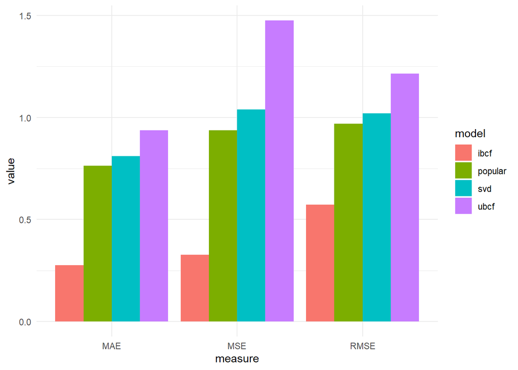

```r
comparison = rbind(rmse_popular, rmse_ubcf, rmse_ibcf, rmse_svd)
comparison = data.frame(comparison, row.names = NULL)
comparison = cbind(model = c('popular', 'ubcf', 'ibcf', 'svd'), comparison)
comparison %>%
  gather('measure', 'value', -1) %>%
  ggplot(aes(x = measure, y = value, fill = model)) + geom_bar(stat = 'identity', position = position_dodge()) + theme_minimal()
```

## Execution Times

```r
model_popular_et
```

```
## Time difference of 34.1348 secs
```

```r
model_ubcf_et
```

```
## Time difference of 6.550761 mins
```

```r
model_ibcf_et
```

```
## Time difference of 23.95119 mins
```

```r
model_svd_et
```

```
## Time difference of 37.55407 secs
```

# PART - VI - SUMMARY AND CONCLUSION

**Platform**: Data Science Virtual Machine on MSFT Azure. Windows (Windows Server 2019 Datacenter). Standard DS3 v2 (4 vcpus, 14 GiB memory).

## Shiny Apps

Based on our observation, we have placed our Shiny Apps at:

1. [System 1](https://bigyanmishra.shinyapps.io/cs598_psl_project4_sys1/)
2. [System 2](https://bigyanmishra.shinyapps.io/cs598_psl_project4_sys2/)

# PART - VII - AKNOWLEDGMENT

We are thankful of Prof. Liang & all TAs for their continued guidance and support.